# AMA LAB 8 : Interpretability and Explainability in Machine Learning

## d) Variable importance with Shapley values

If we compute the variable importance using shapley values we would get the following plots:

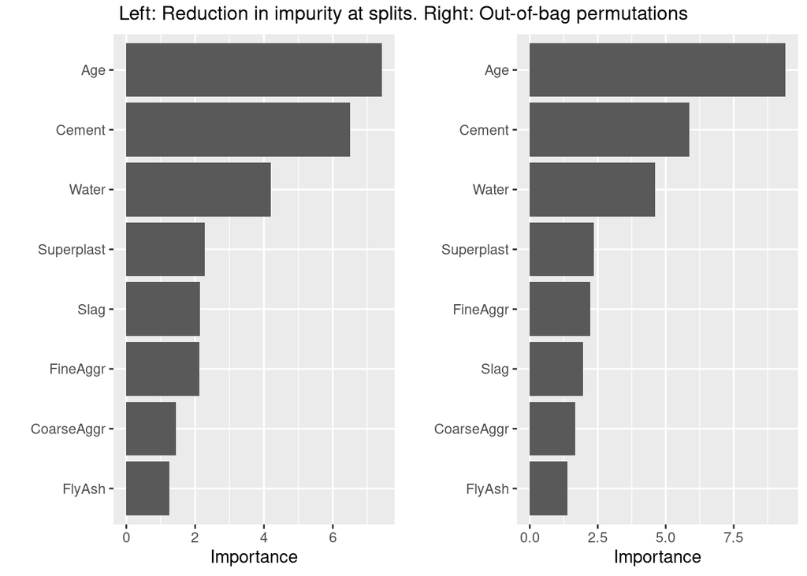

```r
rf_imp_shapley <- vip(rf_impurity, method="shap",
                  pred_wrapper=yhat, num_features = 8,
                  train = concrete_train,
                  newdata = concrete_test[,-9])

rf_oob_shapley <- vip(rf_oob, method="shap",
                  pred_wrapper=yhat, num_features = 8,
                  train = concrete_train,
                  newdata = concrete_test[,-9])

grid.arrange(rf_imp_shapley, rf_oob_shapley, ncol=2, top="Left: Reduction in impurity at splits. Right: Out-of-bag permutations")
```

With the Shapley values, the results that we obtain are very similar for the two models. The main difference is that the ranks in importance between Slag and FineAggr are reversed between the two models. The similarity is logical as the two models are the same but they are constructed randomly.

# 2. Fit a linear model and a gam model:

## a) Summaries

```r
linearModel <- lm(Strength~., data = concrete_train)
(summary_lm <- summary(linearModel))
```

```
##
## Call:
## lm(formula = Strength ~ ., data = concrete_train)
##
## Residuals:
##     Min      1Q  Median      3Q     Max
## -28.566  -6.385   0.574   6.857  35.263
##
## Coefficients:
##              Estimate Std. Error t value Pr(>|t|)
## (Intercept) -5.521940  33.631106  -0.164 0.869628
## Cement       0.117746   0.010613  11.095  < 2e-16 ***
## Slag         0.093833   0.012710   7.383 4.47e-13 ***
## FlyAsh       0.080704   0.015775   5.116 4.05e-07 ***
## Water       -0.168127   0.050434  -3.334 0.000903 ***
## Superplast   0.289666   0.115940   2.498 0.012706 *
## CoarseAggr   0.008933   0.011938   0.748 0.454546
## FineAggr     0.015489   0.013509   1.147 0.251960
## Age          0.110749   0.006502  17.033  < 2e-16 ***
## ---
## Signif. codes:  0 '***' 0.001 '**' 0.01 '*' 0.05 '.' 0.1 ' ' 1
##
## Residual standard error: 10.59 on 691 degrees of freedom
## Multiple R-squared:  0.6071, Adjusted R-squared:  0.6025
## F-statistic: 133.5 on 8 and 691 DF,  p-value: < 2.2e-16
```

```r
model_gam <- gam(Strength~ s(Cement)+s(Slag)+s(FlyAsh)+s(Water)+s(Superplast)+s(CoarseAggr)+s(FineAggr)+s(Age),data=concrete_train)
(summary_gam<-summary(model_gam))
```

```
##
## Family: gaussian
## Link function: identity
##
## Formula:
## Strength ~ s(Cement) + s(Slag) + s(FlyAsh) + s(Water) + s(Superplast) +
##     s(CoarseAggr) + s(FineAggr) + s(Age)
##
## Parametric coefficients:
##             Estimate Std. Error t value Pr(>|t|)
## (Intercept)  36.2460     0.2024   179.1   <2e-16 ***
## ---
## Signif. codes:  0 '***' 0.001 '**' 0.01 '*' 0.05 '.' 0.1 ' ' 1
##
## Approximate significance of smooth terms:
##                 edf Ref.df       F  p-value
## s(Cement)     8.339  8.866  33.865  < 2e-16 ***
## s(Slag)       5.415  6.495  19.543  < 2e-16 ***
## s(FlyAsh)     8.099  8.740   5.409 9.21e-07 ***
## s(Water)      8.731  8.970  20.880  < 2e-16 ***
## s(Superplast) 7.748  8.583   6.666  < 2e-16 ***
## s(CoarseAggr) 7.664  8.526   2.589  0.00702 **
## s(FineAggr)   8.538  8.927  12.052  < 2e-16 ***
## s(Age)        8.433  8.863 250.842  < 2e-16 ***
## ---
## Signif. codes:  0 '***' 0.001 '**' 0.01 '*' 0.05 '.' 0.1 ' ' 1
##
## R-sq.(adj) =  0.898   Deviance explained = 90.7%
## GCV = 31.551  Scale est. = 28.668    n = 700
```

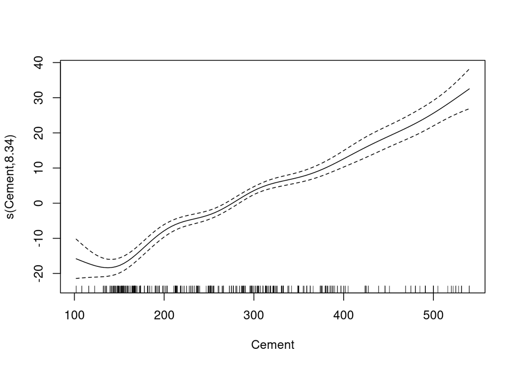

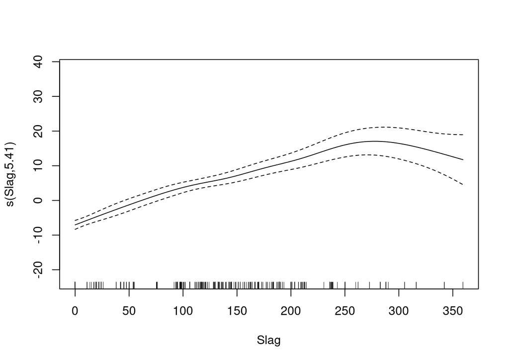

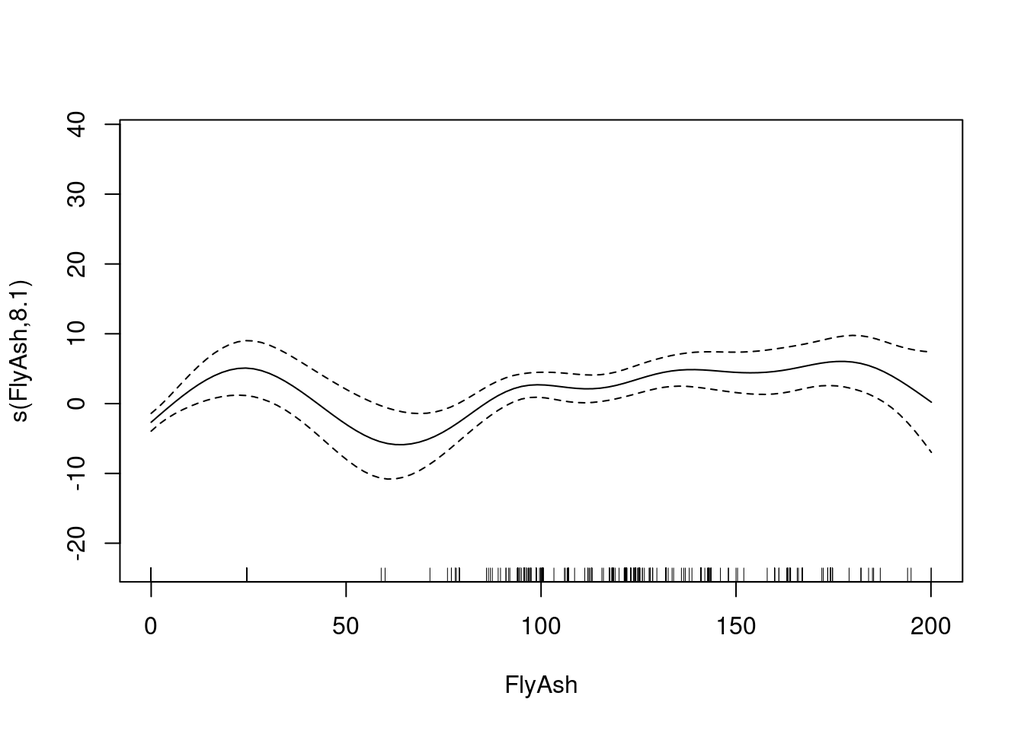

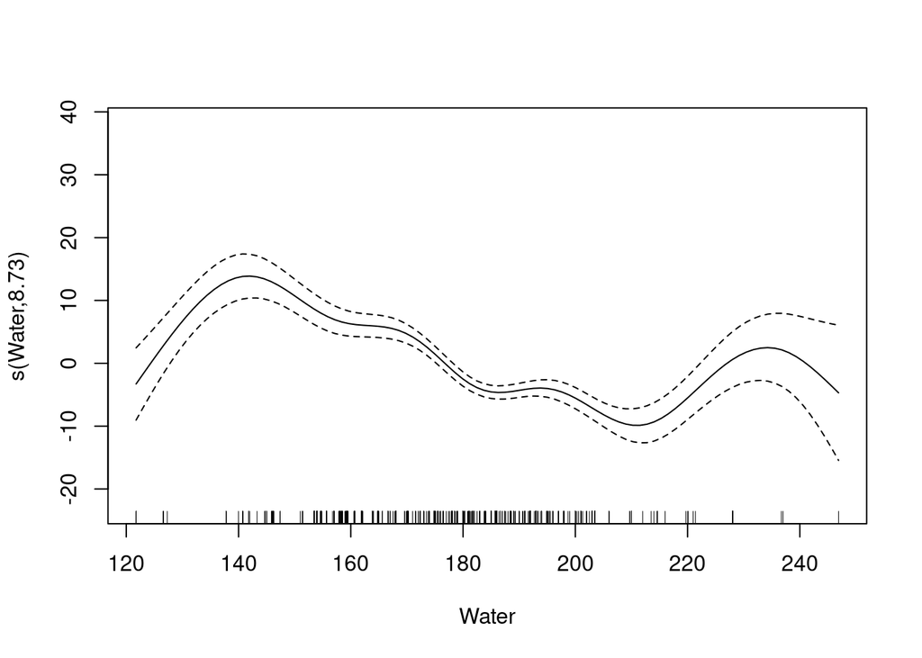

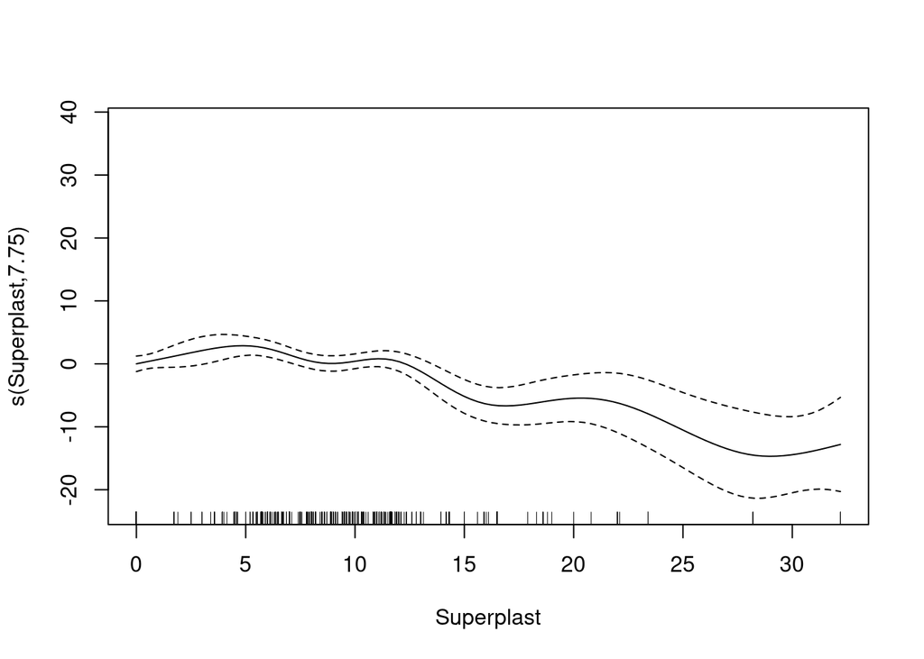

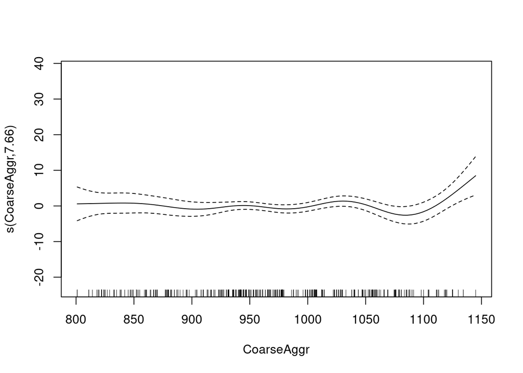

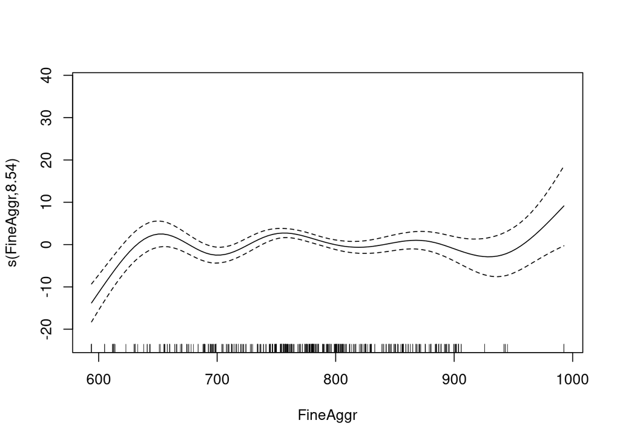

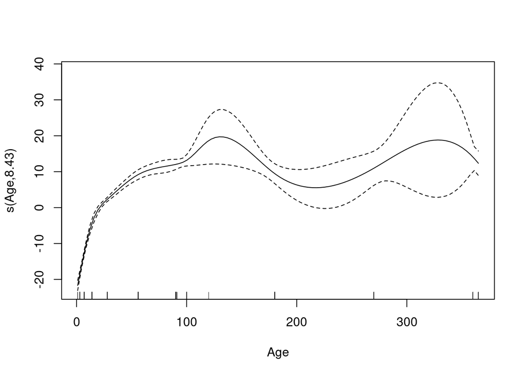

```r
plot(model_gam)
```

## b) Variable importance with Shapley values

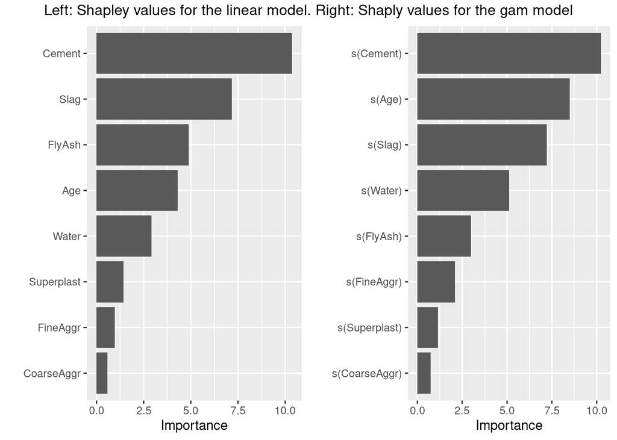

```r
lm_shapley <- vip(linearModel, method="shap",
                  pred_wrapper=predict.lm,
                  train=concrete_train,
                  newdata = concrete_test[,-9],
                  num_features = 8,
                  exact=TRUE)

gam_shapley <- vip(model_gam, method="shap",
                  pred_wrapper=predict.gam,
                  train=concrete_train,
                  newdata = concrete_test[,-9],
                  num_features = 8,
                  exact=TRUE)
par(mfrow = c(1,2))

grid.arrange(lm_shapley, gam_shapley, ncol=2, top="Left: Shapley values for the linear model. Right: Shaply values for the gam model")
```

Next here we can see the plot comparing the shaply values for the linear and gam model. Fist looking at the shaply for the linear model, we can see that the Cement is the most important variable, same can be seen in the gam model. As the second most important variable in the linear model, we can see it is the Slag followed by the FlyAsh, if we compare it with the previous model, we can see that in the linear model and the gam model, the FlyAsh is much more important the in this new models than with the random forest. Looking again at the linear model we can see that the fourth most important variable is the Age, comparing it to the other models, Age is much less important in the linear, as we can see age as the second most important variable in the gam and the most important variable in the all the random forest models. The fifth variable is the water and the fourth in the gam, but there is a gap in the importance, as in the linear we can see a value of around 2.6 and in the gam a value of around double. In the random forest, we can see water is a much more important variable. Lastly we have Superplast, FineAggr, and CoareAggr, in linear model variable importance order, are the least important varables, these are also the least important in the gam model. Compareing it to the random forest model, we can see that the superplast is a more improtant variable, as it is the fourth most important one.